# PLS - Hoteles

Artículo 1, versión 1 (Doctoranda Moreno)

Roberto Gil-Saura

2021-06-02

### 0.0.1 Notas

En este caso, limitamos la sostenibilidad eliminando aquellos ítems que no están funcionando bien a nivel general y tampoco a nivel de grupo. Sigue manteniendo por tanto la sostenibilidad dos de sus tres dimensiones y la segunda dimensión pierde un ítem por poca variabilidad (ítem 121) en la dimensión.

Valorar RVL, pues funciona muy mal en el modelo.

# 1 Análisis del modelo de medida, multigrupo.

Seguidamente mostramos el modelo estructural (*inner model*), establecidos a partir de las hipótesis lanzadas. A lo largo del documento se muestra el modelo general y el modelo multigrupo generado a partir de variable ORIENTACION AL CLIENTE. Sobre la misma se ha generado una clasificación entre ALTA y BAJA, utilizando el criterio de la mediana para realizar la partición. Esta partición se ha validado utilizando también el análisis CLUSTER, donde la optimización de grupos mostraba también como solución satisfactoria los dos grupos, y los criterios KMEANS, PAM y CLARA han mostrado una gran coherencia con esa clasificación inicial.

El modelo estructural es el siguiente:

[interactive chart not shown]

Modelo estructural

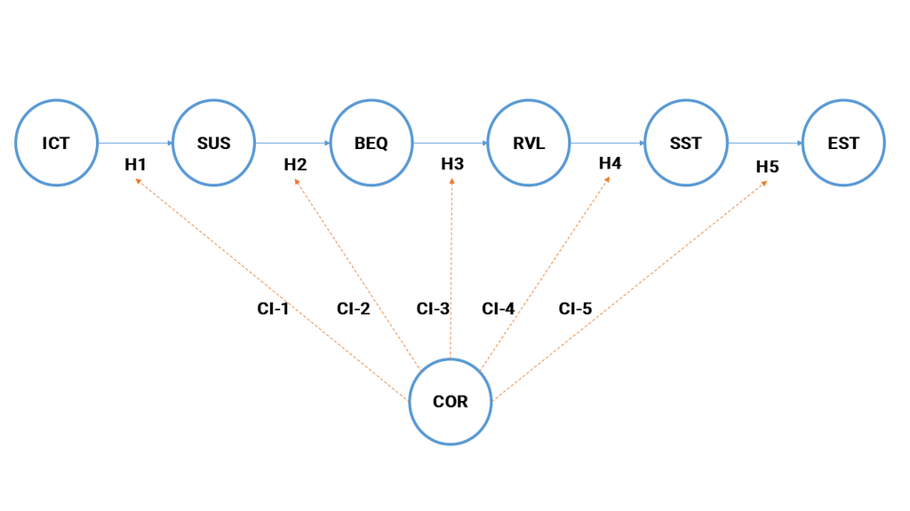

Modelo

## 1.1 Fiabilidad del instrumento de medida

Para el modelo de medida se han considerado constructos de tipo composite mode_A (reflectivos). De este modo, el primer paso debe ser observar el resumen de los indicadores de fiabilidad, consistencia interna y validez.

Comenzamos viendo el *Cronbach’s alpha*, y el resultado del análisis muestra todas las escalas que apoyan las variables latentes tienen un mayor que 0.7, completado por una fiabilidad del compuesto *rhoC* también por encima de 0.7. para valores superiores a 0.9[^1].

```
Modelo
```

```
    alpha  rhoC   AVE  rhoA
ICT 0.855 0.903 0.700 0.856
SUS 0.926 0.935 0.514 0.950
BEQ 0.954 0.966 0.878 0.962
SST 0.856 0.913 0.777 0.872
EST 0.825 0.896 0.742 0.833

Alpha, rhoC, and rhoA should exceed 0.7 while AVE should exceed 0.5
```

```
Modelo grupo 1
```

```
    alpha  rhoC   AVE  rhoA
ICT 0.837 0.892 0.676 0.836
SUS 0.923 0.933 0.506 0.944
BEQ 0.965 0.974 0.905 0.975
SST 0.817 0.891 0.732 0.843
EST 0.848 0.908 0.768 0.854

Alpha, rhoC, and rhoA should exceed 0.7 while AVE should exceed 0.5
```

```
Modelo grupo 2
```

```
    alpha  rhoC   AVE  rhoA
ICT 0.855 0.902 0.697 0.867
SUS 0.915 0.921 0.466 0.954
BEQ 0.942 0.958 0.851 0.951
SST 0.892 0.933 0.822 0.898
EST 0.795 0.880 0.710 0.811

Alpha, rhoC, and rhoA should exceed 0.7 while AVE should exceed 0.5
```

## 1.2 Validez convergente

### 1.2.1 AVE (constructos reflectivos)

El AVE (*average variance extracted*) se define como la cantidad de varianza que un constructo obtiene de sus indicadores con relación a la cantidad de varianza debida al error de medida, recomendándose que su valor sea superior a 0,50 lo que implica que más del 50% de la varianza del constructo es debida a sus indicadores (Fornell y Larcker, 1981).

```
Modelo
```

```
  ICT   SUS   BEQ   SST   EST
0.700 0.514 0.878 0.777 0.742
```

```
Modelo grupo 1
```

```
  ICT   SUS   BEQ   SST   EST
0.676 0.506 0.905 0.732 0.768
```

```
Modelo grupo 2
```

```
  ICT   SUS   BEQ   SST   EST
0.697 0.466 0.851 0.822 0.710
```

Los indicadores son mostrados de forma conjunta en el siguiente gráfico.

```
Modelo
```

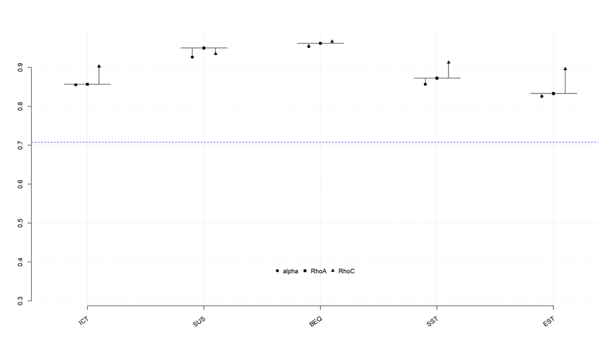

Tabla de fiabilidad

```
Modelo grupo 1
```

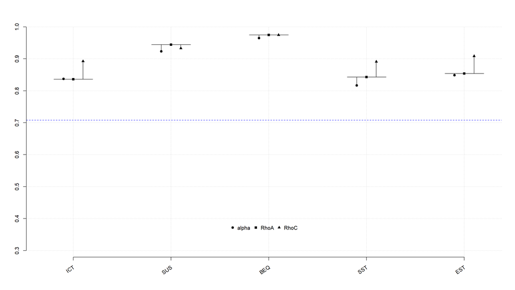

Tabla de fiabilidad

```
Modelo grupo 2
```

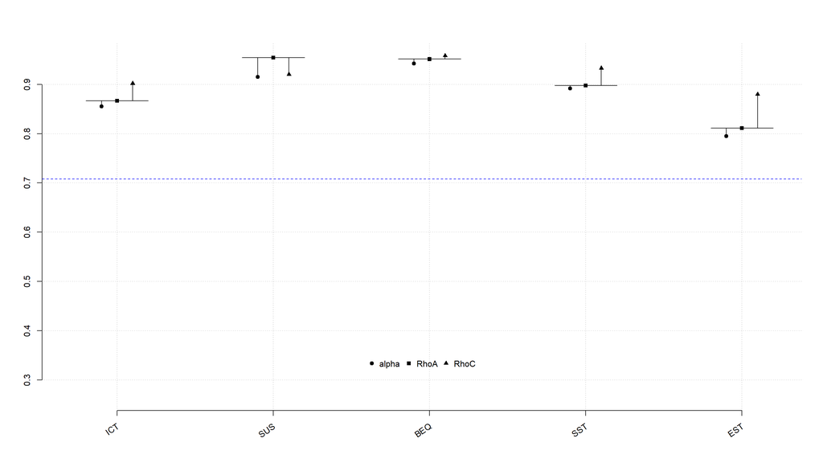

Tabla de fiabilidad

### 1.2.2 Análisis de las cargas (reflectivos) o de los pesos (formativos)

Para la valoración de la validez convergente se analiza también el tamaño de las cargas de los indicadores.

El tamaño de las cargas también es considerado un indicador de fiabilidad; es por ello que todas las cargas de todos los indicadores deberían ser estadísticamente significativas y además su tamaño ser igual o superior[^2] al valor 0,708. Las cargas elevadas sobre un constructo, señalan que los indicadores asociados con el mismo tienen mucho en común y, por lo tanto, capturan correctamente la variable latente. Para aquellas cargas que están entre 0.4 y 0.7 debe ser analizado el comportamiento del constructo ante una eliminación del indicador con carga baja[^3].

```
Modelo
```

```
        ICT   SUS   BEQ   SST   EST
ICT1  0.854 0.000 0.000 0.000 0.000
ICT2  0.884 0.000 0.000 0.000 0.000
ICT3  0.855 0.000 0.000 0.000 0.000
ICT4  0.747 0.000 0.000 0.000 0.000
SUS1  0.000 0.769 0.000 0.000 0.000
SUS2  0.000 0.807 0.000 0.000 0.000
SUS3  0.000 0.761 0.000 0.000 0.000
SUS4  0.000 0.724 0.000 0.000 0.000
SUS5  0.000 0.680 0.000 0.000 0.000
SUS6  0.000 0.806 0.000 0.000 0.000
SUS7  0.000 0.698 0.000 0.000 0.000
SUS8  0.000 0.674 0.000 0.000 0.000
SUS10 0.000 0.805 0.000 0.000 0.000
SUS11 0.000 0.841 0.000 0.000 0.000
SUS12 0.000 0.817 0.000 0.000 0.000
SUS13 0.000 0.510 0.000 0.000 0.000
SUS14 0.000 0.477 0.000 0.000 0.000
SUS15 0.000 0.530 0.000 0.000 0.000
BEQ7  0.000 0.000 0.902 0.000 0.000
BEQ8  0.000 0.000 0.938 0.000 0.000
BEQ9  0.000 0.000 0.954 0.000 0.000
BEQ10 0.000 0.000 0.953 0.000 0.000
SST1  0.000 0.000 0.000 0.818 0.000
SST2  0.000 0.000 0.000 0.929 0.000
SST3  0.000 0.000 0.000 0.894 0.000
EST1  0.000 0.000 0.000 0.000 0.858
EST2  0.000 0.000 0.000 0.000 0.904
EST3  0.000 0.000 0.000 0.000 0.819
```

```
Modelo grupo 1
```

```
        ICT   SUS   BEQ   SST    EST
ICT1  0.868 0.000 0.000 0.000  0.000
ICT2  0.879 0.000 0.000 0.000  0.000
ICT3  0.825 0.000 0.000 0.000 -0.000
ICT4  0.706 0.000 0.000 0.000  0.000
SUS1  0.000 0.789 0.000 0.000  0.000
SUS2  0.000 0.807 0.000 0.000  0.000
SUS3  0.000 0.763 0.000 0.000  0.000
SUS4  0.000 0.768 0.000 0.000  0.000
SUS5  0.000 0.674 0.000 0.000  0.000
SUS6  0.000 0.828 0.000 0.000  0.000
SUS7  0.000 0.702 0.000 0.000  0.000
SUS8  0.000 0.653 0.000 0.000  0.000
SUS10 0.000 0.782 0.000 0.000  0.000
SUS11 0.000 0.818 0.000 0.000  0.000
SUS12 0.000 0.800 0.000 0.000  0.000
SUS13 0.000 0.479 0.000 0.000  0.000
SUS14 0.000 0.458 0.000 0.000  0.000
SUS15 0.000 0.472 0.000 0.000  0.000
BEQ7  0.000 0.000 0.906 0.000  0.000
BEQ8  0.000 0.000 0.944 0.000  0.000
BEQ9  0.000 0.000 0.977 0.000  0.000
BEQ10 0.000 0.000 0.976 0.000  0.000
SST1  0.000 0.000 0.000 0.765  0.000
SST2  0.000 0.000 0.000 0.919  0.000
SST3  0.000 0.000 0.000 0.876  0.000
EST1  0.000 0.000 0.000 0.000  0.898
EST2  0.000 0.000 0.000 0.000  0.896
EST3  0.000 0.000 0.000 0.000  0.833
```

```
Modelo grupo 2
```

```
         ICT   SUS    BEQ   SST    EST
ICT1   0.825 0.000  0.000 0.000  0.000
ICT2   0.867 0.000  0.000 0.000  0.000
ICT3   0.868 0.000  0.000 0.000 -0.000
ICT4   0.777 0.000  0.000 0.000 -0.000
SUS1   0.000 0.702  0.000 0.000  0.000
SUS2   0.000 0.773  0.000 0.000  0.000
SUS3   0.000 0.729 -0.000 0.000  0.000
SUS4   0.000 0.672  0.000 0.000  0.000
SUS5   0.000 0.704  0.000 0.000 -0.000
SUS6   0.000 0.765  0.000 0.000 -0.000
SUS7   0.000 0.692  0.000 0.000 -0.000
SUS8   0.000 0.648  0.000 0.000  0.000
SUS10  0.000 0.793  0.000 0.000  0.000
SUS11  0.000 0.845  0.000 0.000  0.000
SUS12  0.000 0.812  0.000 0.000  0.000
SUS13  0.000 0.386 -0.000 0.000  0.000
SUS14  0.000 0.370 -0.000 0.000  0.000
SUS15  0.000 0.425 -0.000 0.000  0.000
BEQ7   0.000 0.000  0.893 0.000  0.000
BEQ8   0.000 0.000  0.935 0.000  0.000
BEQ9   0.000 0.000  0.931 0.000  0.000
BEQ10  0.000 0.000  0.931 0.000  0.000
SST1   0.000 0.000  0.000 0.868  0.000
SST2   0.000 0.000  0.000 0.938  0.000
SST3   0.000 0.000  0.000 0.914  0.000
EST1   0.000 0.000  0.000 0.000  0.806
EST2   0.000 0.000  0.000 0.000  0.911
EST3  -0.000 0.000  0.000 0.000  0.807
```

## 1.3 Validez discriminante

### 1.3.1 Cross-loadings

Para el análisis de la validez discriminante o capacidad de un constructo de ser realmente distinto a otros, utilizamos las denominadas *cross-loadings*, que miden esa capacidad del constructo. En la tabla adjunta se puede observar en cada indicador carga de forma superior en su variable latente, siendo el resto de cargas de menor intensidad.

```
Modelo
```

```
        ICT   SUS   BEQ   SST   EST
ICT1  0.854 0.367 0.131 0.127 0.081
ICT2  0.884 0.388 0.235 0.168 0.110
ICT3  0.855 0.372 0.276 0.110 0.011
ICT4  0.747 0.365 0.129 0.176 0.051
SUS1  0.282 0.769 0.166 0.225 0.218
SUS2  0.339 0.807 0.145 0.173 0.162
SUS3  0.302 0.761 0.040 0.203 0.143
SUS4  0.286 0.724 0.108 0.237 0.195
SUS5  0.250 0.680 0.166 0.198 0.112
SUS6  0.347 0.806 0.179 0.230 0.104
SUS7  0.323 0.698 0.165 0.104 0.035
SUS8  0.274 0.674 0.111 0.165 0.151
SUS10 0.420 0.805 0.209 0.299 0.201
SUS11 0.434 0.841 0.263 0.309 0.214
SUS12 0.438 0.817 0.309 0.344 0.214
SUS13 0.135 0.510 0.024 0.126 0.104
SUS14 0.176 0.477 0.050 0.143 0.140
SUS15 0.225 0.530 0.041 0.101 0.084
BEQ7  0.207 0.237 0.902 0.323 0.336
BEQ8  0.179 0.152 0.938 0.268 0.277
BEQ9  0.230 0.203 0.954 0.260 0.276
BEQ10 0.249 0.237 0.953 0.277 0.248
SST1  0.212 0.297 0.269 0.818 0.557
SST2  0.140 0.283 0.238 0.929 0.725
SST3  0.122 0.230 0.298 0.894 0.738
EST1  0.039 0.161 0.222 0.630 0.858
EST2  0.118 0.227 0.245 0.725 0.904
EST3  0.031 0.155 0.327 0.631 0.819
```

```
Modelo grupo 1
```

```
        ICT   SUS   BEQ   SST    EST
ICT1  0.868 0.349 0.147 0.106  0.063
ICT2  0.879 0.407 0.245 0.100  0.049
ICT3  0.825 0.388 0.275 0.068 -0.022
ICT4  0.706 0.416 0.151 0.159  0.086
SUS1  0.281 0.789 0.166 0.205  0.212
SUS2  0.357 0.807 0.195 0.201  0.215
SUS3  0.317 0.763 0.086 0.264  0.216
SUS4  0.324 0.768 0.113 0.253  0.229
SUS5  0.283 0.674 0.162 0.264  0.249
SUS6  0.438 0.828 0.190 0.257  0.159
SUS7  0.369 0.702 0.082 0.053  0.068
SUS8  0.303 0.653 0.111 0.128  0.192
SUS10 0.433 0.782 0.188 0.190  0.119
SUS11 0.424 0.818 0.239 0.256  0.188
SUS12 0.454 0.800 0.310 0.323  0.186
SUS13 0.124 0.479 0.038 0.128  0.088
SUS14 0.194 0.458 0.081 0.117  0.153
SUS15 0.216 0.472 0.036 0.060  0.054
BEQ7  0.264 0.196 0.906 0.182  0.237
BEQ8  0.160 0.170 0.944 0.119  0.135
BEQ9  0.245 0.219 0.977 0.149  0.149
BEQ10 0.268 0.254 0.976 0.129  0.115
SST1  0.220 0.313 0.075 0.765  0.519
SST2  0.097 0.251 0.117 0.919  0.678
SST3  0.058 0.190 0.186 0.876  0.719
EST1  0.021 0.183 0.149 0.676  0.898
EST2  0.081 0.253 0.119 0.697  0.896
EST3  0.039 0.176 0.177 0.608  0.833
```

```
Modelo grupo 2
```

```
         ICT   SUS    BEQ   SST    EST
ICT1   0.825 0.307  0.078 0.132  0.053
ICT2   0.867 0.261  0.196 0.242  0.153
ICT3   0.868 0.252  0.251 0.126 -0.009
ICT4   0.777 0.217  0.074 0.175 -0.031
SUS1   0.181 0.702  0.131 0.236  0.183
SUS2   0.223 0.773  0.052 0.124  0.050
SUS3   0.210 0.729 -0.041 0.128  0.024
SUS4   0.196 0.672  0.078 0.208  0.131
SUS5   0.179 0.704  0.152 0.133 -0.040
SUS6   0.145 0.765  0.136 0.188 -0.000
SUS7   0.215 0.692  0.221 0.134 -0.035
SUS8   0.140 0.648  0.080 0.193  0.051
SUS10  0.273 0.793  0.198 0.415  0.250
SUS11  0.333 0.845  0.262 0.358  0.195
SUS12  0.317 0.812  0.286 0.366  0.199
SUS13  0.019 0.386 -0.042 0.103  0.078
SUS14  0.053 0.370 -0.026 0.164  0.089
SUS15  0.095 0.425 -0.008 0.126  0.066
BEQ7   0.115 0.281  0.893 0.453  0.436
BEQ8   0.175 0.132  0.935 0.405  0.422
BEQ9   0.187 0.180  0.931 0.359  0.404
BEQ10  0.190 0.206  0.931 0.404  0.374
SST1   0.215 0.318  0.461 0.868  0.601
SST2   0.178 0.339  0.354 0.938  0.781
SST3   0.157 0.259  0.401 0.914  0.759
EST1   0.001 0.081  0.280 0.582  0.806
EST2   0.124 0.169  0.367 0.750  0.911
EST3  -0.004 0.117  0.473 0.654  0.807
```

### 1.3.2 Fornell-Larcker

El criterio de Fornell-Larcker, compara la raíz cuadrado del *AVE* con la correlación de las variables latentes. La raíz cuadrada del *AVE* de cada constructo, debería ser más grande que la más alta correlación con cualquier otro constructo. Se puede observar en la tabla siguiente que el valor en la diagonal principal, es mayor que el resto de valores en la parte inferior de la matriz.

```
Modelo
```

```
      ICT   SUS   BEQ   SST   EST
ICT 0.836     .     .     .     .
SUS 0.447 0.717     .     .     .
BEQ 0.232 0.225 0.937     .     .
SST 0.174 0.302 0.304 0.882     .
EST 0.076 0.213 0.306 0.771 0.861

FL Criteria table reports square root of AVE on the diagonal and construct correlations on the lower triangle.
```

```
Modelo grupo 1
```

```
      ICT   SUS   BEQ   SST   EST
ICT 0.822     .     .     .     .
SUS 0.480 0.712     .     .     .
BEQ 0.251 0.223 0.951     .     .
SST 0.134 0.284 0.153 0.856     .
EST 0.054 0.234 0.168 0.756 0.876

FL Criteria table reports square root of AVE on the diagonal and construct correlations on the lower triangle.
```

```
Modelo grupo 2
```

```
      ICT   SUS   BEQ   SST   EST
ICT 0.835     .     .     .     .
SUS 0.315 0.682     .     .     .
BEQ 0.178 0.223 0.923     .     .
SST 0.200 0.336 0.444 0.907     .
EST 0.054 0.149 0.445 0.791 0.843

FL Criteria table reports square root of AVE on the diagonal and construct correlations on the lower triangle.
```

### 1.3.3 HTMT

Por último el HTMT es un ratio que si es mayor que 0.90 indica una pérdida de validez discriminante. El ratio HTMT nos indica que los indicadores que pertenecen a una determinada variables latente están correlacionando más como otra variable latente que con la propia. HT/MT> 0.85 Clark & Watson, > 0.90 Gold et al. 2001; Teo et al. 2008).

```
Modelo
```

```
      ICT   SUS   BEQ   SST EST
ICT     .     .     .     .   .
SUS 0.476     .     .     .   .
BEQ 0.254 0.206     .     .   .
SST 0.210 0.325 0.334     .   .
EST 0.098 0.236 0.344 0.907   .
```

```
Modelo grupo 1
```

```
      ICT   SUS   BEQ   SST EST
ICT     .     .     .     .   .
SUS 0.515     .     .     .   .
BEQ 0.272 0.211     .     .   .
SST 0.174 0.330 0.165     .   .
EST 0.086 0.264 0.187 0.895   .
```

```
Modelo grupo 2
```

```
      ICT   SUS   BEQ   SST EST
ICT     .     .     .     .   .
SUS 0.304     .     .     .   .
BEQ 0.202 0.193     .     .   .
SST 0.234 0.330 0.483     .   .
EST 0.129 0.184 0.510 0.929   .
```

# 2 Análisis del modelo estructural

Una vez analizados los constructos desde el punto de vista de su composición, debemos analizar el modelo estructural en su conjunto. Partiendo de que el objetivo del PLS es la maximización de la varianza explicada, las medidas más importantes son la fiabilidad, la validez convergente y la validez discriminante del conjunto del modelo.

- Paths o cargas de latentes…
- R<sup>2</sup>, coeficiente de determinación y/o % de varianza explicada
- f<sup>2</sup> y q<sup>2</sup> efecto tamaño
- Q<sup>2</sup>, relevancia predictiva

## 2.1 Paths y R<sup>2</sup>

```
Modelo
```

```
         SUS   BEQ   SST   EST
R^2    0.200 0.051 0.092 0.595
AdjR^2 0.197 0.047 0.089 0.593
ICT    0.447     .     .     .
SUS        . 0.225     .     .
BEQ        .     . 0.304     .
SST        .     .     . 0.771
```

```
Modelo grupo 1
```

```
         SUS   BEQ   SST   EST
R^2    0.230 0.050 0.024 0.571
AdjR^2 0.225 0.044 0.017 0.568
ICT    0.480     .     .     .
SUS        . 0.223     .     .
BEQ        .     . 0.153     .
SST        .     .     . 0.756
```

```
Modelo grupo 2
```

```
         SUS   BEQ   SST   EST
R^2    0.099 0.050 0.197 0.626
AdjR^2 0.091 0.041 0.190 0.622
ICT    0.315     .     .     .
SUS        . 0.223     .     .
BEQ        .     . 0.444     .
SST        .     .     . 0.791
```

## 2.2 f² - Tamaño del efecto

El f² permite evaluar la contribución de cada constructo exógeno a la R² de un constructo endógeno. Los valores de 0.02, 0.15 y 0.35 indican un efecto pequeño, mediano o grande sobre el constructo endógeno.

```
Modelo
```

```
      ICT   SUS   BEQ   SST   EST
ICT 0.000 0.249 0.000 0.000 0.000
SUS 0.000 0.000 0.053 0.000 0.000
BEQ 0.000 0.000 0.000 0.102 0.000
SST 0.000 0.000 0.000 0.000 1.467
EST 0.000 0.000 0.000 0.000 0.000
```

```
Modelo grupo 1
```

```
      ICT   SUS   BEQ   SST   EST
ICT 0.000 0.299 0.000 0.000 0.000
SUS 0.000 0.000 0.053 0.000 0.000
BEQ 0.000 0.000 0.000 0.024 0.000
SST 0.000 0.000 0.000 0.000 1.331
EST 0.000 0.000 0.000 0.000 0.000
```

```
Modelo grupo 2
```

```
      ICT   SUS   BEQ   SST   EST
ICT 0.000 0.110 0.000 0.000 0.000
SUS 0.000 0.000 0.052 0.000 0.000
BEQ 0.000 0.000 0.000 0.245 0.000
SST 0.000 0.000 0.000 0.000 1.673
EST 0.000 0.000 0.000 0.000 0.000
```

## 2.3 Efectos

### 2.3.1 Totales

```
Modelo
```

```
      ICT   SUS   BEQ   SST   EST
ICT 0.000 0.447 0.101 0.031 0.024
SUS 0.000 0.000 0.225 0.068 0.053
BEQ 0.000 0.000 0.000 0.304 0.234
SST 0.000 0.000 0.000 0.000 0.771
EST 0.000 0.000 0.000 0.000 0.000
```

```
Modelo grupo 1
```

```
      ICT   SUS   BEQ   SST   EST
ICT 0.000 0.480 0.107 0.016 0.012
SUS 0.000 0.000 0.223 0.034 0.026
BEQ 0.000 0.000 0.000 0.153 0.116
SST 0.000 0.000 0.000 0.000 0.756
EST 0.000 0.000 0.000 0.000 0.000
```

```
Modelo grupo 2
```

```
      ICT   SUS   BEQ   SST   EST
ICT 0.000 0.315 0.070 0.031 0.025
SUS 0.000 0.000 0.223 0.099 0.078
BEQ 0.000 0.000 0.000 0.444 0.351
SST 0.000 0.000 0.000 0.000 0.791
EST 0.000 0.000 0.000 0.000 0.000
```

### 2.3.2 Indirectos

```
Modelo
```

```
      ICT   SUS   BEQ   SST   EST
ICT 0.000 0.000 0.101 0.031 0.024
SUS 0.000 0.000 0.000 0.068 0.053
BEQ 0.000 0.000 0.000 0.000 0.234
SST 0.000 0.000 0.000 0.000 0.000
EST 0.000 0.000 0.000 0.000 0.000
```

```
Modelo grupo 1
```

```
      ICT   SUS   BEQ   SST   EST
ICT 0.000 0.000 0.107 0.016 0.012
SUS 0.000 0.000 0.000 0.034 0.026
BEQ 0.000 0.000 0.000 0.000 0.116
SST 0.000 0.000 0.000 0.000 0.000
EST 0.000 0.000 0.000 0.000 0.000
```

```
Modelo grupo 2
```

```
      ICT   SUS   BEQ   SST   EST
ICT 0.000 0.000 0.070 0.031 0.025
SUS 0.000 0.000 0.000 0.099 0.078
BEQ 0.000 0.000 0.000 0.000 0.351
SST 0.000 0.000 0.000 0.000 0.000
EST 0.000 0.000 0.000 0.000 0.000
```

### 2.3.3 it_criteria

```
Modelo
```

```
        SUS     BEQ     SST      EST
AIC -56.640 -10.946 -22.954 -239.004
BIC -49.458  -3.764 -15.772 -231.822
```

```
Modelo grupo 1
```

```
        SUS    BEQ    SST      EST
AIC -38.068 -5.043 -0.744 -129.851
BIC -31.955  1.070  5.369 -123.738
```

```
Modelo grupo 2
```

```
       SUS    BEQ     SST      EST
AIC -8.584 -2.642 -21.367 -106.149
BIC -3.165  2.777 -15.948 -100.730
```

# 3 Modelización con bootstrapping

*Bootstrapping* para calcular la significatividad de los paths estimados y del resto de elementos que usamos para la validación. Habitualmente se trabaja con un 5% (t > 1.96) lo que implica significatividad al 95%. Podemos cambiar al 10 o al 1 según ámbito. Usar doble *bootstrapping* si hay menos de 4 constructos.

## 3.1 Bootstrapped Structural paths

Conjunto de coeficiente path con intervalo de confianza. Los intervalos de confianza no deben contener el 0 para ser significativos.

```
Modelo
```

```
             Original Est. Bootstrap Mean Bootstrap SD T Stat. 2.5% CI 97.5% CI
ICT  ->  SUS         0.447          0.455        0.057   7.768   0.339    0.557
SUS  ->  BEQ         0.225          0.238        0.065   3.439   0.123    0.357
BEQ  ->  SST         0.304          0.304        0.064   4.761   0.148    0.410
SST  ->  EST         0.771          0.769        0.034  22.769   0.716    0.833
```

```
Modelo grupo 1
```

```
             Original Est. Bootstrap Mean Bootstrap SD T Stat. 2.5% CI 97.5% CI
ICT  ->  SUS         0.480          0.509        0.063   7.669   0.395    0.611
SUS  ->  BEQ         0.223          0.241        0.077   2.884   0.099    0.396
BEQ  ->  SST         0.153          0.151        0.086   1.791  -0.031    0.279
SST  ->  EST         0.756          0.764        0.043  17.767   0.678    0.836
```

```
Modelo grupo 2
```

```
             Original Est. Bootstrap Mean Bootstrap SD T Stat. 2.5% CI 97.5% CI
ICT  ->  SUS         0.315          0.351        0.070   4.501   0.236    0.507
SUS  ->  BEQ         0.223          0.257        0.106   2.104   0.032    0.456
BEQ  ->  SST         0.444          0.461        0.072   6.184   0.325    0.582
SST  ->  EST         0.791          0.804        0.044  17.838   0.723    0.898
```

## 3.2 Bootstrapped loadings

Cargas (modelo con constructos reflectivos) con intervalo de confianza. Las cargas deberían ser significativas y mayores a 0.708 dado que este número al cuadrado es 0.50 (Hair et al. 2017).

```
Modelo
```

```
               Original Est. Bootstrap Mean Bootstrap SD T Stat. 2.5% CI 97.5% CI
ICT1  ->  ICT          0.854          0.848        0.023  36.525   0.798    0.894
ICT2  ->  ICT          0.884          0.884        0.017  51.733   0.844    0.912
ICT3  ->  ICT          0.855          0.851        0.023  37.362   0.797    0.885
ICT4  ->  ICT          0.747          0.738        0.041  18.329   0.649    0.814
SUS1  ->  SUS          0.769          0.763        0.038  20.335   0.683    0.824
SUS2  ->  SUS          0.807          0.802        0.036  22.554   0.730    0.859
SUS3  ->  SUS          0.761          0.757        0.037  20.362   0.680    0.820
SUS4  ->  SUS          0.724          0.716        0.057  12.589   0.587    0.805
SUS5  ->  SUS          0.680          0.678        0.040  17.094   0.600    0.754
SUS6  ->  SUS          0.806          0.804        0.029  28.108   0.747    0.856
SUS7  ->  SUS          0.698          0.691        0.048  14.471   0.598    0.776
SUS8  ->  SUS          0.674          0.666        0.036  18.871   0.579    0.720
SUS10  ->  SUS         0.805          0.802        0.027  29.760   0.756    0.847
SUS11  ->  SUS         0.841          0.838        0.019  44.118   0.806    0.876
SUS12  ->  SUS         0.817          0.816        0.022  37.556   0.770    0.851
SUS13  ->  SUS         0.510          0.500        0.062   8.224   0.383    0.604
SUS14  ->  SUS         0.477          0.467        0.064   7.419   0.347    0.585
SUS15  ->  SUS         0.530          0.522        0.061   8.661   0.406    0.619
BEQ7  ->  BEQ          0.902          0.900        0.022  41.886   0.854    0.938
BEQ8  ->  BEQ          0.938          0.936        0.017  53.926   0.897    0.962
BEQ9  ->  BEQ          0.954          0.954        0.012  79.667   0.925    0.973
BEQ10  ->  BEQ         0.953          0.954        0.011  90.535   0.933    0.971
SST1  ->  SST          0.818          0.814        0.038  21.683   0.737    0.873
SST2  ->  SST          0.929          0.928        0.014  64.747   0.897    0.947
SST3  ->  SST          0.894          0.894        0.020  44.401   0.847    0.928
EST1  ->  EST          0.858          0.855        0.032  26.645   0.790    0.907
EST2  ->  EST          0.904          0.901        0.021  43.756   0.849    0.929
EST3  ->  EST          0.819          0.816        0.031  26.496   0.755    0.868
```

```
Modelo grupo 1
```

```
               Original Est. Bootstrap Mean Bootstrap SD T Stat. 2.5% CI 97.5% CI
ICT1  ->  ICT          0.868          0.873        0.024  36.575   0.824    0.911
ICT2  ->  ICT          0.879          0.880        0.028  31.428   0.812    0.921
ICT3  ->  ICT          0.825          0.824        0.035  23.882   0.751    0.873
ICT4  ->  ICT          0.706          0.697        0.065  10.832   0.549    0.803
SUS1  ->  SUS          0.789          0.793        0.040  19.697   0.705    0.856
SUS2  ->  SUS          0.807          0.806        0.033  24.196   0.736    0.862
SUS3  ->  SUS          0.763          0.755        0.050  15.262   0.631    0.838
SUS4  ->  SUS          0.768          0.764        0.040  19.064   0.684    0.829
SUS5  ->  SUS          0.674          0.675        0.052  12.998   0.564    0.770
SUS6  ->  SUS          0.828          0.825        0.031  26.996   0.758    0.879
SUS7  ->  SUS          0.702          0.714        0.061  11.568   0.585    0.819
SUS8  ->  SUS          0.653          0.649        0.062  10.471   0.518    0.751
SUS10  ->  SUS         0.782          0.780        0.047  16.609   0.689    0.860
SUS11  ->  SUS         0.818          0.815        0.028  29.223   0.760    0.863
SUS12  ->  SUS         0.800          0.800        0.035  23.126   0.729    0.858
SUS13  ->  SUS         0.479          0.465        0.100   4.771   0.256    0.629
SUS14  ->  SUS         0.458          0.442        0.094   4.867   0.249    0.618
SUS15  ->  SUS         0.472          0.455        0.103   4.580   0.243    0.634
BEQ7  ->  BEQ          0.906          0.906        0.040  22.848   0.829    0.958
BEQ8  ->  BEQ          0.944          0.937        0.039  23.904   0.843    0.976
BEQ9  ->  BEQ          0.977          0.972        0.032  30.083   0.944    0.988
BEQ10  ->  BEQ         0.976          0.972        0.032  30.507   0.954    0.988
SST1  ->  SST          0.765          0.757        0.061  12.458   0.625    0.852
SST2  ->  SST          0.919          0.920        0.018  51.193   0.889    0.949
SST3  ->  SST          0.876          0.878        0.027  32.000   0.824    0.921
EST1  ->  EST          0.898          0.899        0.022  41.340   0.854    0.937
EST2  ->  EST          0.896          0.897        0.029  30.921   0.833    0.938
EST3  ->  EST          0.833          0.836        0.040  20.882   0.750    0.898
```

```
Modelo grupo 2
```

```
               Original Est. Bootstrap Mean Bootstrap SD T Stat. 2.5% CI 97.5% CI
ICT1  ->  ICT          0.825          0.825        0.051  16.260   0.725    0.906
ICT2  ->  ICT          0.867          0.861        0.047  18.594   0.743    0.925
ICT3  ->  ICT          0.868          0.858        0.044  19.499   0.760    0.925
ICT4  ->  ICT          0.777          0.772        0.060  13.045   0.631    0.870
SUS1  ->  SUS          0.702          0.681        0.087   8.059   0.494    0.820
SUS2  ->  SUS          0.773          0.745        0.084   9.155   0.569    0.871
SUS3  ->  SUS          0.729          0.694        0.102   7.178   0.463    0.857
SUS4  ->  SUS          0.672          0.658        0.076   8.874   0.515    0.792
SUS5  ->  SUS          0.704          0.706        0.070  10.042   0.559    0.824
SUS6  ->  SUS          0.765          0.763        0.059  13.041   0.649    0.857
SUS7  ->  SUS          0.692          0.680        0.067  10.249   0.542    0.788
SUS8  ->  SUS          0.648          0.624        0.076   8.577   0.472    0.761
SUS10  ->  SUS         0.793          0.782        0.049  16.275   0.672    0.862
SUS11  ->  SUS         0.845          0.840        0.033  25.782   0.782    0.892
SUS12  ->  SUS         0.812          0.806        0.043  18.996   0.710    0.869
SUS13  ->  SUS         0.386          0.358        0.141   2.737   0.026    0.584
SUS14  ->  SUS         0.370          0.344        0.140   2.646   0.032    0.561
SUS15  ->  SUS         0.425          0.401        0.136   3.115   0.093    0.594
BEQ7  ->  BEQ          0.893          0.896        0.025  36.312   0.852    0.941
BEQ8  ->  BEQ          0.935          0.936        0.027  35.220   0.864    0.969
BEQ9  ->  BEQ          0.931          0.935        0.024  38.197   0.879    0.966
BEQ10  ->  BEQ         0.931          0.935        0.022  42.934   0.886    0.966
SST1  ->  SST          0.868          0.864        0.034  25.664   0.792    0.920
SST2  ->  SST          0.938          0.933        0.019  49.409   0.893    0.962
SST3  ->  SST          0.914          0.911        0.017  53.382   0.880    0.941
EST1  ->  EST          0.806          0.805        0.075  10.708   0.618    0.904
EST2  ->  EST          0.911          0.912        0.016  58.615   0.884    0.941
EST3  ->  EST          0.807          0.799        0.041  19.836   0.708    0.858
```

## 3.3 Bootstrapped HTMT

```
Modelo
```

```
             Original Est. Bootstrap Mean Bootstrap SD T Stat. 2.5% CI 97.5% CI
ICT  ->  SUS         0.476          0.477        0.070   6.791   0.340    0.594
ICT  ->  BEQ         0.254          0.251        0.067   3.783   0.129    0.384
ICT  ->  SST         0.210          0.212        0.057   3.684   0.113    0.307
ICT  ->  EST         0.098          0.126        0.046   2.137   0.066    0.226
SUS  ->  BEQ         0.206          0.227        0.058   3.569   0.129    0.349
SUS  ->  SST         0.325          0.329        0.054   5.965   0.219    0.422
SUS  ->  EST         0.236          0.237        0.061   3.865   0.128    0.375
BEQ  ->  SST         0.334          0.333        0.070   4.793   0.161    0.447
BEQ  ->  EST         0.344          0.348        0.067   5.124   0.215    0.455
SST  ->  EST         0.907          0.906        0.039  23.154   0.833    0.971
```

```
Modelo grupo 1
```

```
             Original Est. Bootstrap Mean Bootstrap SD T Stat. 2.5% CI 97.5% CI
ICT  ->  SUS         0.515          0.534        0.075   6.897   0.399    0.661
ICT  ->  BEQ         0.272          0.285        0.078   3.509   0.126    0.417
ICT  ->  SST         0.174          0.215        0.067   2.594   0.095    0.345
ICT  ->  EST         0.086          0.139        0.055   1.550   0.062    0.275
SUS  ->  BEQ         0.211          0.235        0.071   2.966   0.117    0.387
SUS  ->  SST         0.330          0.351        0.070   4.734   0.229    0.470
SUS  ->  EST         0.264          0.280        0.075   3.507   0.141    0.444
BEQ  ->  SST         0.165          0.176        0.077   2.143   0.057    0.316
BEQ  ->  EST         0.187          0.201        0.083   2.257   0.063    0.346
SST  ->  EST         0.895          0.905        0.059  15.109   0.779    1.009
```

```
Modelo grupo 2
```

```
             Original Est. Bootstrap Mean Bootstrap SD T Stat. 2.5% CI 97.5% CI
ICT  ->  SUS         0.304          0.336        0.087   3.483   0.206    0.519
ICT  ->  BEQ         0.202          0.227        0.086   2.346   0.079    0.379
ICT  ->  SST         0.234          0.246        0.094   2.475   0.103    0.435
ICT  ->  EST         0.129          0.190        0.053   2.422   0.113    0.321
SUS  ->  BEQ         0.193          0.240        0.071   2.711   0.125    0.377
SUS  ->  SST         0.330          0.353        0.087   3.794   0.215    0.495
SUS  ->  EST         0.184          0.250        0.065   2.842   0.159    0.368
BEQ  ->  SST         0.483          0.500        0.079   6.094   0.357    0.638
BEQ  ->  EST         0.510          0.505        0.081   6.320   0.348    0.657
SST  ->  EST         0.929          0.942        0.047  19.888   0.865    1.035
```

## 3.4 Bootstrapped total effects

Para la comprobación de los coeficientes b del modelo y conocer que son significativos.

```
Modelo
```

```
             Original Est. Bootstrap Mean Bootstrap SD T Stat. 2.5% CI 97.5% CI
ICT  ->  SUS         0.447          0.455        0.057   7.768   0.339    0.557
ICT  ->  BEQ         0.101          0.109        0.035   2.911   0.049    0.175
ICT  ->  SST         0.031          0.034        0.014   2.126   0.012    0.065
ICT  ->  EST         0.024          0.026        0.011   2.128   0.009    0.049
SUS  ->  BEQ         0.225          0.238        0.065   3.439   0.123    0.357
SUS  ->  SST         0.068          0.074        0.029   2.361   0.024    0.134
SUS  ->  EST         0.053          0.057        0.022   2.362   0.018    0.099
BEQ  ->  SST         0.304          0.304        0.064   4.761   0.148    0.410
BEQ  ->  EST         0.234          0.234        0.051   4.598   0.110    0.332
SST  ->  EST         0.771          0.769        0.034  22.769   0.716    0.833
```

```
Modelo grupo 1
```

```
             Original Est. Bootstrap Mean Bootstrap SD T Stat. 2.5% CI 97.5% CI
ICT  ->  SUS         0.480          0.509        0.063   7.669   0.395    0.611
ICT  ->  BEQ         0.107          0.124        0.046   2.320   0.046    0.221
ICT  ->  SST         0.016          0.021        0.015   1.126   0.000    0.050
ICT  ->  EST         0.012          0.016        0.011   1.090   0.000    0.038
SUS  ->  BEQ         0.223          0.241        0.077   2.884   0.099    0.396
SUS  ->  SST         0.034          0.039        0.027   1.255  -0.002    0.096
SUS  ->  EST         0.026          0.030        0.021   1.243   0.001    0.072
BEQ  ->  SST         0.153          0.151        0.086   1.791  -0.031    0.279
BEQ  ->  EST         0.116          0.116        0.066   1.745  -0.025    0.208
SST  ->  EST         0.756          0.764        0.043  17.767   0.678    0.836
```

```
Modelo grupo 2
```

```
             Original Est. Bootstrap Mean Bootstrap SD T Stat. 2.5% CI 97.5% CI
ICT  ->  SUS         0.315          0.351        0.070   4.501   0.236    0.507
ICT  ->  BEQ         0.070          0.090        0.043   1.612   0.010    0.169
ICT  ->  SST         0.031          0.043        0.024   1.299   0.005    0.086
ICT  ->  EST         0.025          0.034        0.020   1.249   0.004    0.071
SUS  ->  BEQ         0.223          0.257        0.106   2.104   0.032    0.456
SUS  ->  SST         0.099          0.121        0.056   1.753   0.017    0.222
SUS  ->  EST         0.078          0.097        0.045   1.722   0.015    0.177
BEQ  ->  SST         0.444          0.461        0.072   6.184   0.325    0.582
BEQ  ->  EST         0.351          0.371        0.061   5.765   0.267    0.491
SST  ->  EST         0.791          0.804        0.044  17.838   0.723    0.898
```

# 4 Modelos

Representamos los modelos con su valores de trabajo obtenidos.

## 4.1 Modelo general

```
Modelo
```

[interactive chart not shown]

Modelo con bootstrapping

## 4.2 Modelo grupo 1

```
Modelo grupo 1
```

[interactive chart not shown]

Modelo con bootstrapping

## 4.3 Modelo grupo 2

```
Modelo grupo 2
```

[interactive chart not shown]

Modelo con bootstrapping

# 5 Predicción (seminr)

## 5.1 Modelo general

[output not shown]

```
PLS in-sample metrics:
      SUS1  SUS2  SUS3  SUS4  SUS5  SUS6  SUS7  SUS8 SUS10 SUS11 SUS12 SUS13 SUS14 SUS15  BEQ7  BEQ8  BEQ9 BEQ10  SST1  SST2  SST3  EST1  EST2  EST3
RMSE 1.203 1.153 0.832 0.851 0.990 1.113 1.200 0.913 1.027 1.015 1.043 0.772 0.749 0.729 1.299 1.200 1.216 1.190 1.058 0.955 1.133 0.760 0.711 1.007
MAE  0.960 0.934 0.638 0.655 0.737 0.883 0.930 0.626 0.809 0.803 0.811 0.614 0.605 0.566 1.015 0.927 0.950 0.928 0.767 0.757 0.940 0.548 0.526 0.721

PLS out-of-sample metrics:
      SUS1  SUS2  SUS3  SUS4  SUS5  SUS6  SUS7  SUS8 SUS10 SUS11 SUS12 SUS13 SUS14 SUS15  BEQ7  BEQ8  BEQ9 BEQ10  SST1  SST2  SST3  EST1  EST2  EST3
RMSE 1.230 1.178 0.846 0.867 1.011 1.127 1.239 0.945 1.048 1.033 1.056 0.777 0.756 0.733 1.320 1.214 1.234 1.208 1.076 0.967 1.143 0.775 0.719 1.014
MAE  0.981 0.958 0.653 0.669 0.758 0.895 0.962 0.641 0.823 0.816 0.822 0.620 0.613 0.571 1.025 0.934 0.959 0.937 0.781 0.766 0.950 0.552 0.530 0.729

LM in-sample metrics:
      SUS1  SUS2  SUS3  SUS4  SUS5  SUS6  SUS7  SUS8 SUS10 SUS11 SUS12 SUS13 SUS14 SUS15  BEQ7  BEQ8  BEQ9 BEQ10  SST1  SST2  SST3  EST1  EST2  EST3
RMSE 1.097 1.058 0.771 0.779 0.882 1.026 1.075 0.791 0.945 0.938 0.919 0.730 0.708 0.686 1.112 1.092 1.083 1.051 0.751 0.613 0.655 0.645 0.620 0.820
MAE  0.885 0.853 0.579 0.592 0.637 0.812 0.826 0.608 0.753 0.767 0.742 0.575 0.574 0.537 0.890 0.854 0.856 0.843 0.567 0.472 0.495 0.484 0.472 0.606

LM out-of-sample metrics:
      SUS1  SUS2  SUS3  SUS4  SUS5  SUS6  SUS7  SUS8 SUS10 SUS11 SUS12 SUS13 SUS14 SUS15  BEQ7  BEQ8  BEQ9 BEQ10  SST1  SST2  SST3  EST1  EST2  EST3
RMSE 1.319 1.294 0.935 0.957 1.031 1.223 1.252 1.012 1.167 1.117 1.030 0.874 0.843 0.816 1.489 1.354 1.352 1.329 1.008 0.859 0.845 0.868 0.775 1.107
MAE  1.028 1.011 0.686 0.703 0.727 0.964 0.961 0.720 0.903 0.880 0.837 0.664 0.661 0.625 1.152 1.043 1.051 1.037 0.738 0.632 0.636 0.646 0.589 0.787
```

## 5.2 Modelo grupo 1

```
Modelo grupo 1
```

```
PLS in-sample metrics:
      SUS1  SUS2  SUS3  SUS4  SUS5  SUS6  SUS7  SUS8 SUS10 SUS11 SUS12 SUS13 SUS14 SUS15  BEQ7  BEQ8  BEQ9 BEQ10  SST1  SST2  SST3  EST1  EST2  EST3
RMSE 1.205 1.154 0.832 0.851 0.990 1.113 1.202 0.914 1.027 1.015 1.043 0.772 0.748 0.728 1.299 1.200 1.216 1.190 1.058 0.955 1.133 0.759 0.710 1.006
MAE  0.961 0.935 0.638 0.655 0.738 0.883 0.932 0.627 0.810 0.803 0.812 0.614 0.604 0.565 1.014 0.927 0.949 0.927 0.767 0.757 0.940 0.547 0.525 0.721

PLS out-of-sample metrics:
      SUS1  SUS2  SUS3  SUS4  SUS5  SUS6  SUS7  SUS8 SUS10 SUS11 SUS12 SUS13 SUS14 SUS15  BEQ7  BEQ8  BEQ9 BEQ10  SST1  SST2  SST3  EST1  EST2  EST3
RMSE 1.216 1.166 0.846 0.861 1.009 1.125 1.215 0.928 1.043 1.035 1.055 0.782 0.768 0.739 1.329 1.221 1.241 1.215 1.073 0.965 1.147 0.779 0.728 1.019
MAE  0.969 0.944 0.649 0.663 0.750 0.897 0.947 0.634 0.820 0.817 0.818 0.620 0.617 0.573 1.037 0.939 0.967 0.944 0.778 0.765 0.954 0.559 0.535 0.732

LM in-sample metrics:
      SUS1  SUS2  SUS3  SUS4  SUS5  SUS6  SUS7  SUS8 SUS10 SUS11 SUS12 SUS13 SUS14 SUS15  BEQ7  BEQ8  BEQ9 BEQ10  SST1  SST2  SST3  EST1  EST2  EST3
RMSE 1.098 1.062 0.771 0.778 0.881 1.029 1.076 0.790 0.946 0.936 0.919 0.728 0.708 0.684 1.117 1.087 1.081 1.050 0.749 0.617 0.654 0.647 0.618 0.823
MAE  0.886 0.857 0.579 0.592 0.636 0.817 0.828 0.608 0.755 0.766 0.743 0.574 0.574 0.536 0.894 0.852 0.854 0.842 0.565 0.474 0.494 0.486 0.472 0.608

LM out-of-sample metrics:
      SUS1  SUS2  SUS3  SUS4  SUS5  SUS6  SUS7  SUS8 SUS10 SUS11 SUS12 SUS13 SUS14 SUS15  BEQ7  BEQ8  BEQ9 BEQ10  SST1  SST2  SST3  EST1  EST2  EST3
RMSE 1.307 1.254 0.940 0.976 1.047 1.194 1.235 1.026 1.157 1.150 1.031 0.895 0.839 0.835 1.422 1.410 1.378 1.342 1.042 0.806 0.843 0.837 0.786 1.076
MAE  1.021 0.986 0.682 0.698 0.738 0.926 0.934 0.732 0.871 0.885 0.833 0.678 0.664 0.635 1.123 1.071 1.075 1.063 0.758 0.608 0.626 0.617 0.589 0.772
```

## 5.3 Modelo grupo 2

```
Modelo grupo 2
```

```
PLS in-sample metrics:
      SUS1  SUS2  SUS3  SUS4  SUS5  SUS6  SUS7  SUS8 SUS10 SUS11 SUS12 SUS13 SUS14 SUS15  BEQ7  BEQ8  BEQ9 BEQ10  SST1  SST2  SST3  EST1  EST2  EST3
RMSE 1.179 1.278 0.986 1.012 1.334 1.374 1.547 0.861 1.140 1.196 1.255 0.695 0.701 0.670 1.528 1.451 1.478 1.505 1.140 1.073 1.215 0.958 0.734 1.095
MAE  0.951 0.971 0.736 0.751 0.974 1.058 1.156 0.643 0.938 0.975 1.041 0.567 0.551 0.539 1.234 1.167 1.161 1.192 0.916 0.819 0.923 0.692 0.507 0.785

PLS out-of-sample metrics:
      SUS1  SUS2  SUS3  SUS4  SUS5  SUS6  SUS7  SUS8 SUS10 SUS11 SUS12 SUS13 SUS14 SUS15  BEQ7  BEQ8  BEQ9 BEQ10  SST1  SST2  SST3  EST1  EST2  EST3
RMSE 1.204 1.304 1.015 1.035 1.361 1.398 1.575 0.877 1.157 1.224 1.276 0.701 0.709 0.677 1.579 1.520 1.541 1.564 1.187 1.124 1.263 0.974 0.755 1.115
MAE  0.969 0.991 0.755 0.772 0.999 1.074 1.179 0.653 0.952 0.997 1.053 0.574 0.557 0.546 1.286 1.237 1.225 1.256 0.951 0.860 0.960 0.705 0.519 0.805

LM in-sample metrics:
      SUS1  SUS2  SUS3  SUS4  SUS5  SUS6  SUS7  SUS8 SUS10 SUS11 SUS12 SUS13 SUS14 SUS15  BEQ7  BEQ8  BEQ9 BEQ10  SST1  SST2  SST3  EST1  EST2  EST3
RMSE 1.061 1.171 0.917 0.916 1.181 1.169 1.310 0.800 0.997 1.054 1.098 0.649 0.651 0.637 1.096 1.017 1.006 1.050 0.804 0.531 0.685 0.705 0.544 0.831
MAE  0.833 0.881 0.684 0.663 0.833 0.902 0.991 0.557 0.769 0.853 0.886 0.495 0.485 0.477 0.855 0.823 0.778 0.833 0.598 0.391 0.514 0.558 0.394 0.632

LM out-of-sample metrics:
      SUS1  SUS2  SUS3  SUS4  SUS5  SUS6  SUS7  SUS8 SUS10 SUS11 SUS12 SUS13 SUS14 SUS15  BEQ7  BEQ8  BEQ9 BEQ10  SST1  SST2  SST3  EST1  EST2  EST3
RMSE 1.253 1.442 1.117 1.126 1.395 1.404 1.588 0.957 1.125 1.272 1.277 0.754 0.773 0.735 1.602 1.497 1.446 1.490 1.273 0.854 1.008 1.053 0.947 1.247
MAE  0.968 1.060 0.823 0.805 0.996 1.088 1.189 0.678 0.878 1.021 1.019 0.591 0.577 0.562 1.224 1.166 1.068 1.143 0.888 0.612 0.732 0.779 0.656 0.923
```

# 6 Bibliografía

- Clark, L. y Watson, D. (1995). Constructing validity: basic issues in objective scale development. Psychological Assessment, 7(3):309—319.
- Gold, A. , Malhotra, A. , y Segars, A. (2001). Knowledge management: An organizational capabilities perspective. Journal of Management Information Systems, 18(1):185—214.
- Hair Jr., Joseph F.; G. Tomas M. Hult; Christian M. Ringle; Marko Sarstedt. (2017) A Primer on Partial Least Squares Structural Equation Modeling (PLS-SEM). SAGE Publications. 2ª edición, Kindle.
- Aldás Manzano, J., & Uriel Jimenez, E. (2017). Análisis multivariante aplicado con R. Ediciones Paraninfo, SA.
- Champely, S. (2020). pwr: Basic Functions for Power Analysis. R package version 1.3-0. https://CRAN.R-project.org/package=pwr
- Cohen, J. (1988). Statistical power analysis for the behavioral sciences (2nd ed.). Hillsdale,NJ: Lawrence Erlbaum.
- Chin, W.W., 1998. The partial least squares approach to structural equation modelling. In G. A. Marcoulides (Ed.), Modern methods for business research, 295-336. Mahwah, NJ: Lawrence Erlbaum Associates.
- Demin, Gregory. 2020. Expss: Tables, Labels and Some Useful Functions from Spreadsheets and ‘SPSS’ Statistics. https://CRAN.R-project.org/package=expss.
- Falk, R. F. y Miller, N. B., 1992. A primer for soft modeling. Ohio: University of Akron Press.
- Gold, A., Malhotra, A., y Segars, A. (2001). Knowledge management: An organizational capabilities perspective. Journal of Management Information Systems, 18(1):185—214.
- Gil, R., 2021. Tablas y gráficos con R y R Studio. 1st ed. [ebook] València, ISBN: 978-84-09-29382-7; disponible en: https://tables.investigaonline.com.
- Hair, J.F., Hult, G. T.M., Ringle, C.M., & Sarstedt, M., 2017. A primer on partial least squares structural equation modelling (PLS-SEM) (2nd ed.). Thousand Oaks, CA: Sage.
- Henseler, J., Ringle, C.M., & Sarstedt, M., 2016. Testing measurement invariance of com- posites using partial least squares. International Marketing Review, 33(3), 405-431.
- Joreskog, K.G., 1978. Structural analysis of covariance and correlation matrices. Psychometrika, 43, 443-477.
- R Core Team (2021). R: A language and environment for statistical computing. R Foundation for Statistical Computing, Vienna, Austria.URL https://www.R-project.org/.
- Ray, S., Danks, N.P.& Calero, A. (2021). seminr: Domain-Specific Language for Building and Estimating Structural Equation Models. R package version 2.0.1. https://CRAN.R-project.org/package=seminr.
[^1]: En https://forum.smartpls.com/viewtopic.php?f=5&t=3805 hay una “discusión en torno al”greater than 0.9" de Primer PLS … de Hair; lo solventa un investigador / desarrollador de SmartPLS: https://www.researchgate.net/profile/Jan_Michael_Becker
[^2]: El cuadrado de una carga estandarizada de un indicador representa cuanto de la variación en un ítem se explica por el constructo, y se describe como la varianza extraída del ítem. Una regla de oro que se establece es que una variable latente explicaría una parte sustancial de la varianza de cada indicador, usualmente al menos el 50%. Esto implica que la varianza compartida entre el constructo y sus indicadores, es mayor que la varianza del error de medida. Esto significa que la carga de un indicador debería ser mayor de 0,708 puesto que ese número al cuadrado (0,7082) es igual a 0,50. (Hair *et al.,* 2017: 113).
[^3]: En nuestro caso al proceder con la eliminación de aquellas cargas menores de 0.7 no mejoraba significativamente el modelo